# **Exploring the NOAA Storm Database**

David Bryan Lao

September 01, 2020

## **Synopsis**

In this work, we explored the NOAA Storm Database. We looked into the most harmful and the most economically-consequential events. For the most harmful, we did this by looking at events that have both mean injuries and mean fatalities above the third quartile for each respective variable, simultaneously. We did a similar analysis for the most economically-consequential events, but with the following quantities as basis: mean property damage and mean crop damage. The result shows that the topmost harmful and the topmost economically-consequential event is `Tropical Storm Gordon`.

## **Data Processing**

```r
library(dplyr)
library(ggplot2)
```

We begin this analysis by first reading in the data. We do this by reading in the CSV file into the variable `data`:

```r
data <- read.csv("repdata_data_StormData.csv.bz2")
```

Now, let’s explore `data`. We start by taking the `head()` of the `data`:

```r
head(data)
```

```
##   STATE__           BGN_DATE BGN_TIME TIME_ZONE COUNTY COUNTYNAME STATE  EVTYPE
## 1       1  4/18/1950 0:00:00     0130       CST     97     MOBILE    AL TORNADO
## 2       1  4/18/1950 0:00:00     0145       CST      3    BALDWIN    AL TORNADO
## 3       1  2/20/1951 0:00:00     1600       CST     57    FAYETTE    AL TORNADO
## 4       1   6/8/1951 0:00:00     0900       CST     89    MADISON    AL TORNADO
## 5       1 11/15/1951 0:00:00     1500       CST     43    CULLMAN    AL TORNADO
## 6       1 11/15/1951 0:00:00     2000       CST     77 LAUDERDALE    AL TORNADO
##   BGN_RANGE BGN_AZI BGN_LOCATI END_DATE END_TIME COUNTY_END COUNTYENDN
## 1         0                                               0         NA
## 2         0                                               0         NA
## 3         0                                               0         NA
## 4         0                                               0         NA
## 5         0                                               0         NA
## 6         0                                               0         NA
##   END_RANGE END_AZI END_LOCATI LENGTH WIDTH F MAG FATALITIES INJURIES PROPDMG
```

[output cut: 20 more lines]

The dimension of `data` obtained by `dim()` is:

```r
dim(data)
```

```
## [1] 902297     37
```

And finally, we get a nice little summary of `data`:

```r
summary(data)
```

```
##     STATE__       BGN_DATE           BGN_TIME          TIME_ZONE
##  Min.   : 1.0   Length:902297      Length:902297      Length:902297
##  1st Qu.:19.0   Class :character   Class :character   Class :character
##  Median :30.0   Mode  :character   Mode  :character   Mode  :character
##  Mean   :31.2
##  3rd Qu.:45.0
##  Max.   :95.0
##
##      COUNTY       COUNTYNAME           STATE              EVTYPE
##  Min.   :  0.0   Length:902297      Length:902297      Length:902297
##  1st Qu.: 31.0   Class :character   Class :character   Class :character
##  Median : 75.0   Mode  :character   Mode  :character   Mode  :character
##  Mean   :100.6
##  3rd Qu.:131.0
##  Max.   :873.0
##
##    BGN_RANGE          BGN_AZI           BGN_LOCATI          END_DATE
##  Min.   :   0.000   Length:902297      Length:902297      Length:902297
##  1st Qu.:   0.000   Class :character   Class :character   Class :character
##  Median :   0.000   Mode  :character   Mode  :character   Mode  :character
##  Mean   :   1.484
##  3rd Qu.:   1.000
##  Max.   :3749.000
##
##    END_TIME           COUNTY_END COUNTYENDN       END_RANGE
##  Length:902297      Min.   :0    Mode:logical   Min.   :  0.0000
##  Class :character   1st Qu.:0    NA's:902297    1st Qu.:  0.0000
##  Mode  :character   Median :0                   Median :  0.0000
##                     Mean   :0                   Mean   :  0.9862
##                     3rd Qu.:0                   3rd Qu.:  0.0000
##                     Max.   :0                   Max.   :925.0000
##
##    END_AZI           END_LOCATI            LENGTH              WIDTH
##  Length:902297      Length:902297      Min.   :   0.0000   Min.   :   0.000
##  Class :character   Class :character   1st Qu.:   0.0000   1st Qu.:   0.000
##  Mode  :character   Mode  :character   Median :   0.0000   Median :   0.000
##                                        Mean   :   0.2301   Mean   :   7.503
##                                        3rd Qu.:   0.0000   3rd Qu.:   0.000
##                                        Max.   :2315.0000   Max.   :4400.000
##
```

[output cut: 25 more lines]

```
##  Min.   :-14451   Min.   :   0   Min.   :-14455   Length:902297
##  1st Qu.:  7247   1st Qu.:   0   1st Qu.:     0   Class :character
##  Median :  8707   Median :   0   Median :     0   Mode  :character
##  Mean   :  6940   Mean   :1452   Mean   :  3509
##  3rd Qu.:  9605   3rd Qu.:3549   3rd Qu.:  8735
##  Max.   : 17124   Max.   :9706   Max.   :106220
##                   NA's   :40
##      REFNUM
##  Min.   :     1
##  1st Qu.:225575
##  Median :451149
##  Mean   :451149
##  3rd Qu.:676723
##  Max.   :902297
##
```

### **Question One**

Now, our first task is to answer the following question: Across the United States, which types of events (as indicated in the `EVTYPE` variable) are most harmful with respect to population health?

To do this, we create a data frame `events` with only the following columns: `INJURIES`, `FATALITIES`, and `EVTYPE`.

```r
events <- data %>% select('INJURIES', 'FATALITIES', 'EVTYPE')
```

Next, we aggregate `events` by `EVTYPE` with the `mean()` function:

```r
events_agg <- aggregate(events[, 1:2], by = list(events$EVTYPE), FUN = mean)
names(events_agg)[names(events_agg) == "Group.1"] <- "EVTYPE"
```

Now, you may be thinking why I took the mean instead of the sum. It would be natural to just find the event with the most number of injuries or fatalities, right? That might be true. But in my analysis here, I took the mean because I wanted to find out which events are most destructive **on average**. For example, say that we have `1000` typhoons in a year with `20` deaths per typhoon. Meanwhile, we have `100` tornados in a year with `50` deaths per tornado. While it is valid to take the total deaths as basis (`20000` for typhoons and `5000` for tornados), it would also be equally valid to take the average deaths (`20` for typhoons and `50` for tornados) and use that as basis for comparing their harmfulness. It all depends on how you view harmfulness, is it its cumulative effect or is it its average effect? For the former, you are looking at how harmful it is based on its effects over the years while for the latter, you are looking how harmful it is on average. This argument is carried over to Question Two, as well.

```r
harmful <- events_agg %>% filter(INJURIES != 0 & FATALITIES != 0)
```

To find the most harmful events, we take the upper `25` percent of the mean injuries column and the upper `25` percent of the mean fatalities column from our `harmful` data frame via an `AND` logical operator (this means that we are only counting high mean injuries and high mean fatalities events as most harmful):

```r
most_harmful <- harmful %>% filter(INJURIES >= quantile(INJURIES, 0.75) & FATALITIES >= quantile(FATALITIES, 0.75))
```

### **Question Two**

Our second task is to answer the following question: Across the United States, which types of events have the greatest economic consequences?

To do this, we create a data frame `damages` with only the following columns: `PROPDMG`, `CROPDMG`, and `EVTYPE`. Note that our analysis here will be similar to the one we did in Question One.

```r
damages <- data %>% select('PROPDMG', 'CROPDMG', 'EVTYPE')
```

We aggregate `damages` by `EVTYPE` with the `mean()` function:

```r
damages_agg <- aggregate(damages[, 1:2], by = list(events$EVTYPE), FUN = mean)
names(damages_agg)[names(damages_agg) == "Group.1"] <- "EVTYPE"
```

```r
consequential <- damages_agg %>% filter(PROPDMG != 0 & CROPDMG != 0)
```

To find the most consequential events, we take the upper `25` percent of the mean property damage column and the upper `25` percent of the mean crop damage column from our `consequential` data via an `AND` logical operator (this means that we are only counting high mean property damage and high mean crop damage events as most consequential):

```r
most_consequential <- consequential %>% filter(PROPDMG >= quantile(PROPDMG, 0.75) & CROPDMG >= quantile(CROPDMG, 0.75))
```

## **Results**

### **Question One**

We now plot our `most harmful` data frame with `log(MEAN INJURIES)` in the horizontal axis and `log(MEAN FATALITIES)` in the vertical axis:

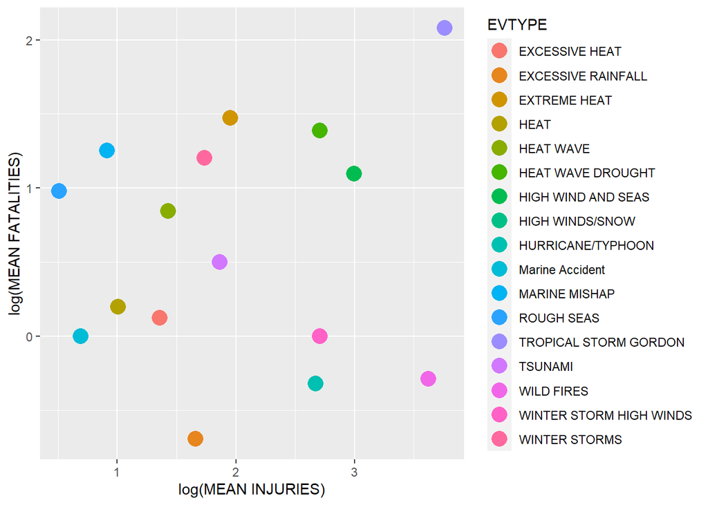

```r
ggplot(most_harmful, aes(log(INJURIES), log(FATALITIES), color = EVTYPE)) + geom_point(size = 5) + labs(x = 'log(MEAN INJURIES)', y = 'log(MEAN FATALITIES)')
```

This plot shows our most harmful events with `Tropical Storm Gordon`, on the upper right, taking the top of the list.

### **Question Two**

We now plot our `most consequential` data frame with `log(MEAN PROPDMG)` in the horizontal axis and `log(MEAN CROPDMG)` in the vertical axis:

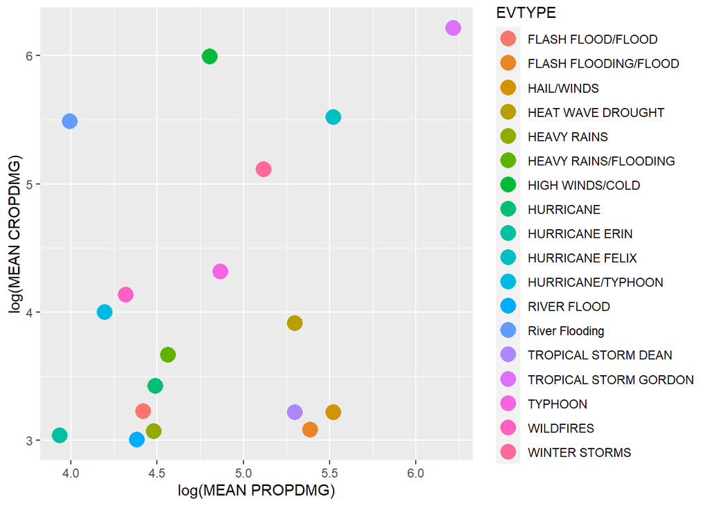

```r
ggplot(most_consequential, aes(log(PROPDMG), log(CROPDMG), color = EVTYPE)) + geom_point(size = 5) + labs(x = 'log(MEAN PROPDMG)', y = 'log(MEAN CROPDMG)')
```

This plot shows our most economically-consequential events with, again, `Tropical Storm Gordon`, on the upper right, taking the top of the list.